# Exercise week 2

Shawn Schneidereit

2021-04-25

## McElreath chapter 2.6, exercises 2M(1-7), extra: 2H(1-4)

### 2M1.

Recall the globe tossing model from the chapter. Compute and plot the grid approximate posterior distribution for each of the following sets of observations. In each case, assume a uniform prior for p. (1) W,W,W (2) W,W,W,L (3) L,W,W,L,W,W,W

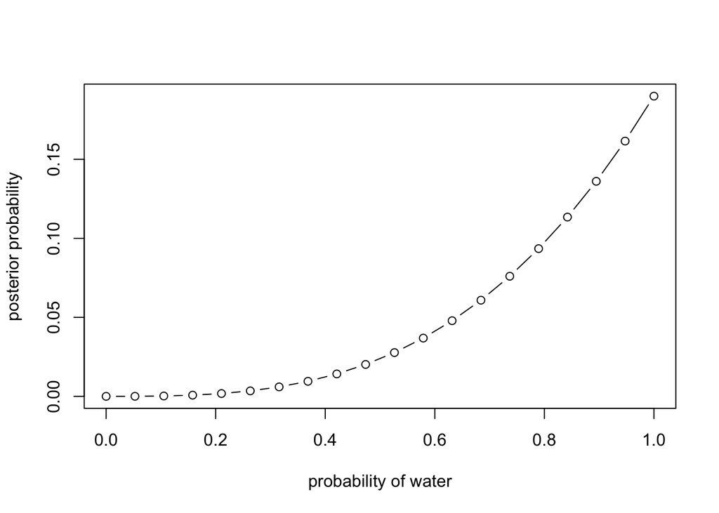

```r
# (1) W,W,W
p_grid <- seq(from = 0, to = 1, length.out = 20)
prior <- rep(1, 20)
likelihood <- dbinom(3, size = 3, prob = p_grid)
unstd.posterior <- likelihood * prior
posterior <- unstd.posterior / sum(unstd.posterior)
plot(p_grid, posterior, type = "b",
  xlab = "probability of water", ylab = "posterior probability")
```

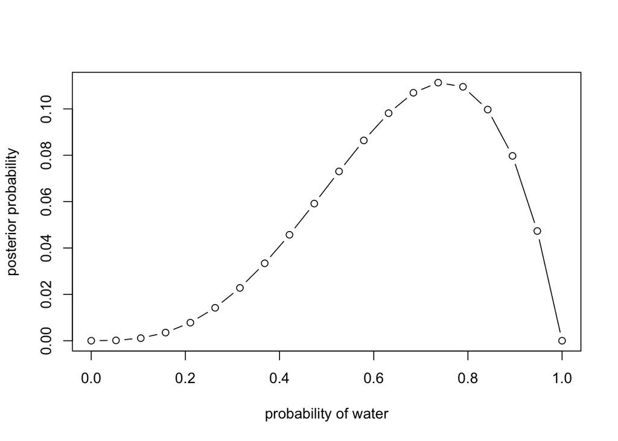

```r
# (2) W,W,W,L
p_grid <- seq(from = 0, to = 1, length.out = 20)
prior <- rep(1, 20)
likelihood <- dbinom(3, size = 4, prob = p_grid)
unstd.posterior <- likelihood * prior
posterior <- unstd.posterior / sum(unstd.posterior)
plot(p_grid, posterior, type = "b",
  xlab = "probability of water", ylab = "posterior probability")
```

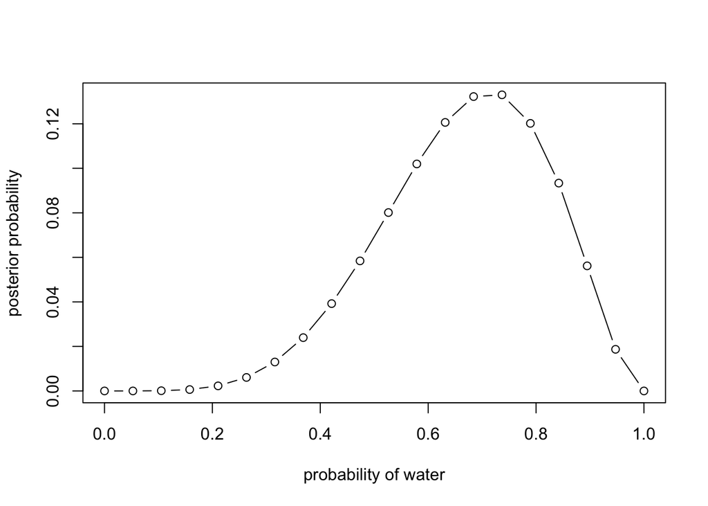

```r
# (3) L,W,W,L,W,W,W
p_grid <- seq(from = 0, to = 1, length.out = 20)
prior <- rep(1, 20)
likelihood <- dbinom(5, size = 7, prob = p_grid)
unstd.posterior <- likelihood * prior
posterior <- unstd.posterior / sum(unstd.posterior)
plot(p_grid, posterior, type = "b",
  xlab = "probability of water", ylab = "posterior probability")
```

### 2M2.

Now assume a prior for p that is equal to zero when p < 0.5 and is a positive constant when p ≥ 0.5. Again compute and plot the grid approximate posterior distribution for each of the sets of observations in the problem just above.

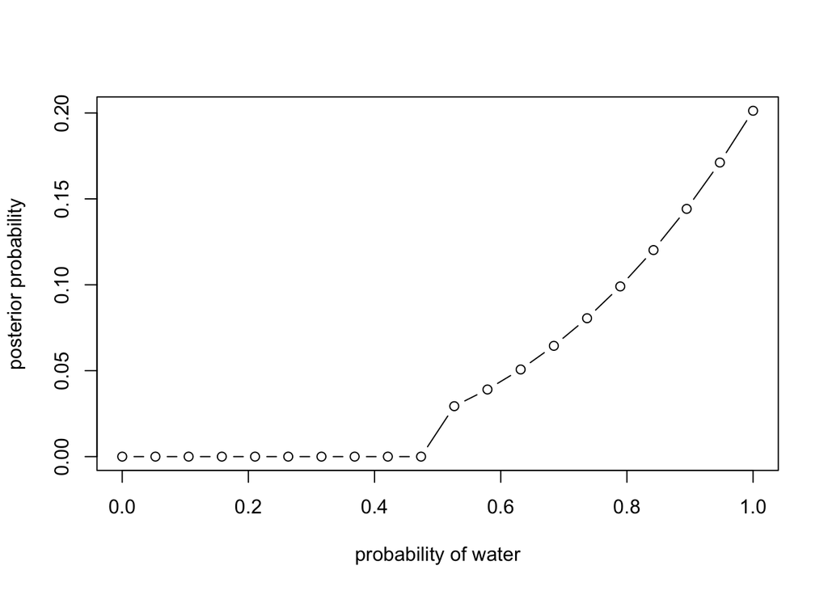

```r
# (1) W,W,W
p_grid <- seq(from = 0, to = 1, length.out = 20)
#prior <- c(rep(0, 10), rep(1,10))
# more elegant ifelse
prior <- ifelse(p_grid < 0.5, 0, 1)
likelihood <- dbinom(3, size = 3, prob = p_grid)
unstd.posterior <- likelihood * prior
posterior <- unstd.posterior / sum(unstd.posterior)
plot(p_grid, posterior, type = "b",
  xlab = "probability of water", ylab = "posterior probability")
```

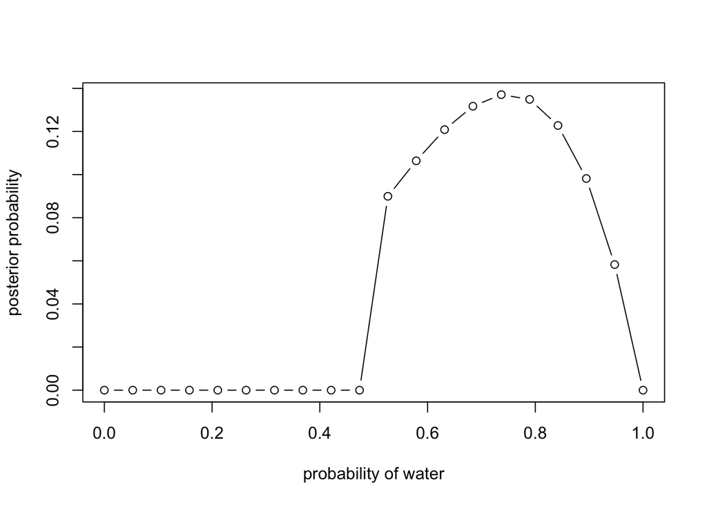

```r
# (2) W,W,W,L
p_grid <- seq(from = 0, to = 1, length.out = 20)
prior <- ifelse(p_grid < 0.5, 0, 1)
likelihood <- dbinom(3, size = 4, prob = p_grid)
unstd.posterior <- likelihood * prior
posterior <- unstd.posterior / sum(unstd.posterior)
plot(p_grid, posterior, type = "b",
  xlab = "probability of water", ylab = "posterior probability")
```

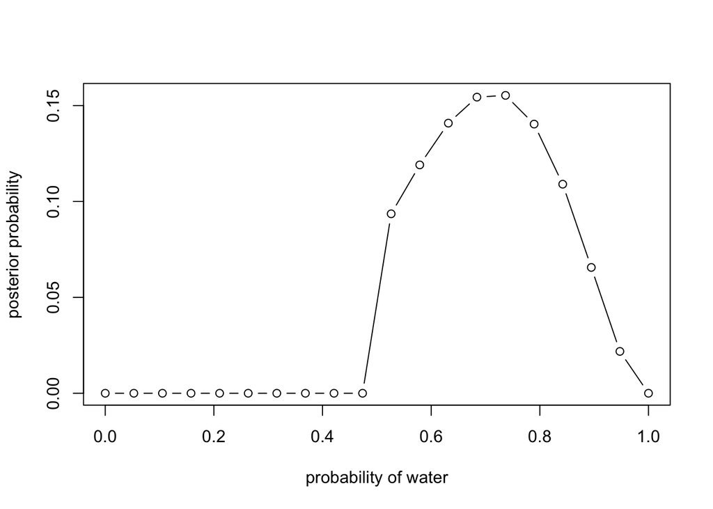

```r
# (3) L,W,W,L,W,W,W
p_grid <- seq(from = 0, to = 1, length.out = 20)
prior <- ifelse(p_grid < 0.5, 0, 1)
likelihood <- dbinom(5, size = 7, prob = p_grid)
unstd.posterior <- likelihood * prior
posterior <- unstd.posterior / sum(unstd.posterior)
plot(p_grid, posterior, type = "b",
  xlab = "probability of water", ylab = "posterior probability")
```

### 2M3.

Suppose there are two globes, one for Earth and one for Mars. The Earth globe is 70% covered in water. The Mars globe is 100% land. Further suppose that one of these globes—you don’t know which—was tossed in the air and produced a “land” observation. Assume that each globe was equally likely to be tossed. Show that the posterior probability that the globe was the Earth, conditional on seeing “land” (Pr(Earth|land)), is 0.23.

Pr(land|Earth) = 1–0.7 = 0.3 Pr(land|Mars)=1 Pr(Earth) = Pr(Mars) = 0.5

```r
# probobaliy of getting land and tossing earth
# Pr(land|Earth)
0.3 * 0.5
```

```
## [1] 0.15
```

```r
# 0.15

# total pr of there being land pr(land)
# Pr(land|Earth) * Pr(Earth) + Pr(land|Mars) * Pr(Mars)
0.3 * 0.5 + 1 * 0.5
```

```
## [1] 0.65
```

```r
# 0.65

# the probability of tossing earth and getting land Pr(Earth|land)
0.15 / 0.65
```

```
## [1] 0.2307692
```

### 2M4.

Suppose you have a deck with only three cards. Each card has two sides, and each side is either black or white. One card has two black sides. The second card has one black and one white side. The third card has two white sides. Now suppose all three cards are placed in a bag and shuffled. Someone reaches into the bag and pulls out a card and places it flat on a table. A black side is shown facing up, but you don’t know the color of the side facing down. Show that the probability that the other side is also black is 2/3. Use the counting method (Section 2 of the chapter) to approach this problem. This means counting up the ways that each card could produce the observed data (a black side facing up on the table). card1=bb card2=bw card3=ww

It is impossible that the its card 3, as we know that black was shown. Given this, there are two options (card1 and chard2), that could produce a black side. card1+card2 have a total option pool of 3b and 1w, but as one black has been shown, we are left with 2b and 1w. Therefore the chance of the face down side to be also black is 2/3 (total three option left, of which two are back)

### 2M5.

Now suppose there are four cards: B/B, B/W, W/W, and another B/B. Again suppose a card is drawn from the bag and a black side appears face up. Again calculate the probability that the other side is black.

card1=bb card2=bw card3=ww card4=bb

### 2M6.

Imagine that black ink is heavy,and so cards with black sides are heavier than cards with white sides. As a result, it’s less likely that a card with black sides is pulled from the bag. So again assume there are three cards: B/B, B/W, and W/W. After experimenting a number of times, you conclude that for every way to pull the B/B card from the bag, there are 2 ways to pull the B/W card and 3 ways to pull the W/W card. Again suppose that a card is pulled and a black side appears face up. Show that the probability the other side is black is now 0.5. Use the counting method, as before.

```r
# this time I wrote the solution as code to better follow the steps
ways <- c(2, 1, 0) # WW = 0 as we have seen a black side and can thus eleminate it from the pool
prior <- c(1, 2, 3)
likelihood <- ways * prior
p <- likelihood / sum(likelihood)
# for the first column (BB), we have a 0.5 probability
```

### 2M7.

Assume again the original card problem ,with as single card showing a black side faceup. Before looking at the other side, we draw another card from the bag and lay it face up on the table. The face that is shown on the new card is white. Show that the probability that the first card, the one showing a black side, has black on its other side is now 0.75. Use the counting method, if you can. Hint: Treat this like the sequence of globe tosses, counting all the ways to see each observation, for each possible first card.

If the first card we pull is the BB then there are three ways to pull a white the secound time (WB;WW = 3W:1B). The same occures on the secound side of the BB. So there are 6 ways (3 + 3) for the fist card to be black. If we pull the BW card first, we only have one total option path and there are only 2 ways to pull a white the secound time (BB;WW = 2W;2B).

We can calculate the probability of the first card being BB by dividing the number of ways given BB by the total number of ways

```r
6/(6+2)
```

```
## [1] 0.75
```

```r
#0.75
```